# Analysis of Rohwer Data with MMRA

Michael Friendly, Matthew Sigal

08 Jun 2016

This script reproduces all of the analysis and graphs for the MMRA of the Rohwer data in the paper and also includes other analyses not described there. It is set up as an R script that can be “compiled” to HTML, Word, or PDF using `knitr::knit()`. This is most convenient within R Studio via the `File -> Compile Notebook` option.

## Load packages and the data (subsetted)

```r
library(car)
library(heplots)

data("Rohwer", package="heplots")
Rohwer2 <- subset(Rohwer, subset=group==2)
rownames(Rohwer2)<- 1:nrow(Rohwer2) # apply rownames
```

## fit the multivariate regression model, test hypotheses

Here, we use `linearHypothesis` to test the overall null, *B = 0*

```r
rohwer.mod <- lm(cbind(SAT, PPVT, Raven) ~ n + s + ns + na + ss, data=Rohwer2)
Anova(rohwer.mod)
```

```
##
## Type II MANOVA Tests: Pillai test statistic
##    Df test stat approx F num Df den Df Pr(>F)
## n   1     0.202     2.02      3     24 0.1376
## s   1     0.310     3.59      3     24 0.0284 *
## ns  1     0.358     4.46      3     24 0.0126 *
## na  1     0.465     6.96      3     24 0.0016 **
## ss  1     0.089     0.78      3     24 0.5173
## ---
## Signif. codes:  0 '***' 0.001 '**' 0.01 '*' 0.05 '.' 0.1 ' ' 1
```

```r
print(linearHypothesis(rohwer.mod,
                       c("n", "s", "ns", "na", "ss")), SSP=FALSE)
```

```
##
## Multivariate Tests:
##                  Df test stat approx F num Df den Df   Pr(>F)
## Pillai            5    1.0386    2.753     15  78.00 0.001912 **
## Wilks             5    0.2431    2.974     15  66.65 0.001154 **
## Hotelling-Lawley  5    2.0615    3.115     15  68.00 0.000697 ***
## Roy               5    1.4654    7.620      5  26.00 0.000160 ***
## ---
## Signif. codes:  0 '***' 0.001 '**' 0.01 '*' 0.05 '.' 0.1 ' ' 1
```

## View univariate coeffcients:

```r
(rohwer.coef <- coef(rohwer.mod)[-1,])
```

```
##        SAT     PPVT    Raven
## n   3.2571  0.06728  0.05935
## s   2.9966  0.36998  0.49244
## ns -5.8591 -0.37438 -0.16402
## na  5.6662  1.52301  0.11898
## ss -0.6227  0.41016 -0.12116
```

Alternatively, we can view all coefficients and significance values using the `tidy()` function in the `broom` package

```r
library(broom)
tidy(rohwer.mod)
```

```
##    response        term  estimate std.error statistic   p.value
## 1       SAT (Intercept) -28.46747   25.7190   -1.1069 2.785e-01
## 2       SAT           n   3.25713    1.2958    2.5136 1.848e-02
## 3       SAT           s   2.99658    1.5000    1.9977 5.631e-02
## 4       SAT          ns  -5.85906    1.5450   -3.7924 8.016e-04
## 5       SAT          na   5.66622    1.3384    4.2335 2.537e-04
## 6       SAT          ss  -0.62265    1.1406   -0.5459 5.898e-01
## 7      PPVT (Intercept)  39.69709   12.2687    3.2356 3.298e-03
## 8      PPVT           n   0.06728    0.6181    0.1088 9.142e-01
## 9      PPVT           s   0.36998    0.7155    0.5171 6.095e-01
## 10     PPVT          ns  -0.37438    0.7370   -0.5080 6.157e-01
## 11     PPVT          na   1.52301    0.6385    2.3854 2.464e-02
## 12     PPVT          ss   0.41016    0.5441    0.7538 4.577e-01
## 13    Raven (Intercept)  13.24384    2.6143    5.0660 2.824e-05
## 14    Raven           n   0.05935    0.1317    0.4506 6.560e-01
## 15    Raven           s   0.49244    0.1525    3.2298 3.346e-03
## 16    Raven          ns  -0.16402    0.1570   -1.0445 3.059e-01
## 17    Raven          na   0.11898    0.1360    0.8746 3.898e-01
## 18    Raven          ss  -0.12116    0.1159   -1.0450 3.056e-01
```

## Fit separate univariate models models to prepare *Table 1* in the paper

For a publication-quality summary table of the coefficients, it is most convenient to fit the separate models for each response.

```r
rohwer.mod1 <- lm(SAT   ~ n + s + ns + na + ss, data = Rohwer2)
rohwer.mod2 <- lm(PPVT  ~ n + s + ns + na + ss, data = Rohwer2)
rohwer.mod3 <- lm(Raven ~ n + s + ns + na + ss, data = Rohwer2)
```

## summary table for univariate models:

The `stargazer` package creates nice tables in HTML, LaTeX or just ASCII text. There are many, many options.

```r
library(stargazer, quietly=TRUE)
stargazer(rohwer.mod1, rohwer.mod2, rohwer.mod3,
          type = "text", digits=2,
          omit.table.layout = "#",
          star.cutoffs = c(0.05, 0.01, 0.001),
          omit = "Constant",
          title="Univariate regression models for Rohwer data")
```

```
##
## Univariate regression models for Rohwer data
## =============================================================
##                                     Dependent variable:
##                               -------------------------------
##                                   SAT       PPVT      Raven
## -------------------------------------------------------------
## n                                3.26*      0.07      0.06
##                                 (1.30)     (0.62)    (0.13)
##
## s                                3.00       0.37     0.49**
##                                 (1.50)     (0.72)    (0.15)
##
## ns                             -5.86***     -0.37     -0.16
##                                 (1.54)     (0.74)    (0.16)
##
## na                              5.67***     1.52*     0.12
##                                 (1.34)     (0.64)    (0.14)
##
## ss                               -0.62      0.41      -0.12
##                                 (1.14)     (0.54)    (0.12)
##
## -------------------------------------------------------------
## Observations                      32         32        32
## R2                               0.56       0.35      0.31
## Adjusted R2                      0.47       0.23      0.18
## Residual Std. Error (df = 26)    25.67      12.25     2.61
## F Statistic (df = 5; 26)        6.54***     2.85*     2.32
## =============================================================
## Note:                           *p<0.05; **p<0.01; ***p<0.001
```

## Visualize the MMRA model

Set colors to use in the following plots. They correspond to the **E** ellipse and the **H** ellipses for all hypotheses.

```r
cols <-  c("red", "blue", "black", "darkgreen", "darkcyan",
           "magenta", "gray20")
```

HE plot, with ellipse to test all 5 regressors

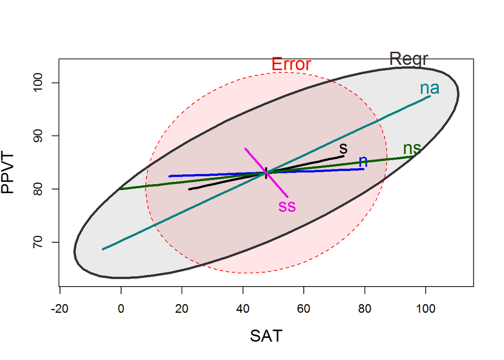

```r
hyp <- list("Regr" = c("n", "s", "ns", "na", "ss"))
heplot(rohwer.mod,
       hypotheses = hyp,
       fill=TRUE, fill.alpha=0.1, cex=1.5, cex.lab=1.4, col=cols,
       lwd=c(1,3))
```

## View all pairs of HE plots

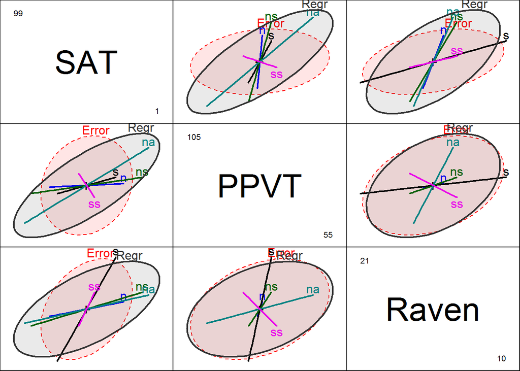

```r
pairs(rohwer.mod, hypotheses=hyp, col=cols, var.cex=4,
      fill=TRUE, fill.alpha=0.1, cex=1.5)
```